# DATA 603 Assignment 4

Michael Ellsworth

December 6, 2019

# Problem 1

*Numerous factors contribute to the smooth running of an electric motor (“Increasing Market Share Through Improved Product and Process Design: An Experimental Approach,” Quality Engineering, 1991: 361-369). In particular, it is desirable to keep motor noise and vibration to a minimum. To study the effect that the brand of bearing has on motor vibration, five different motor bearing brands were examined by installing each type of bearing on different random samples of six motors. The amount of motor vibration (measured in microns) was recorded when each of the 30 motors was running. The data for this study is given in the data file vibration.csv*

## a

*What are the response variable and an experimental unit?*

- The response variable is vibration (microns)
- The experimental unit is the motor

## b

*What is the treatment and how many treatment levels of this experiment?*

- The treatment is the brand bearing
- There are 5 treatment levels; brand1, brand2, brand3, brand4 and brand5

## c

*Write the hypotheses testing, test and conclude if the average amount of motor vibrations are different at significance level = 0.05.*

Hypothesis test:

$$\begin{aligned}
H_0:& \mu_\text{brand1} = \mu_\text{brand2} = \mu_\text{brand3} = \mu_\text{brand4} = \mu_\text{brand5} \\
H_a:& \text{ at least one } \mu_\text{brandi} \text{ is different } i = 1, 2, 3, 4, 5
\end{aligned}$$

```
##             Df Sum Sq Mean Sq F value   Pr(>F)
## brand        4  30.86   7.714   8.444 0.000187 ***
## Residuals   25  22.84   0.914
## ---
## Signif. codes:  0 '***' 0.001 '**' 0.01 '*' 0.05 '.' 0.1 ' ' 1
```

From the summary of the anova test, the P-value of the hypothesis is less than 0.05, which means we can reject $H_0$ and conclude that the average amount of motor vibrations are different amongst the motors for at least one motor brand.

## d

*Construct the Anova table for the test.*

| Source of Variation | Df | Sum of Squares | Mean Squares | F-Statistic | P-Value |
| --- | --- | --- | --- | --- | --- |
| Between Treatments | 4 | 30.86 | 7.715 | 8.44461471103327 | 0.000187 |
| Error within Treatments | 25 | 22.84 | 0.9136 |  |  |
| Total | 29 | 53.7 |  |  |  |

## e

*Construct the boxplots for all levels. Do you detect any influencial outliers?*

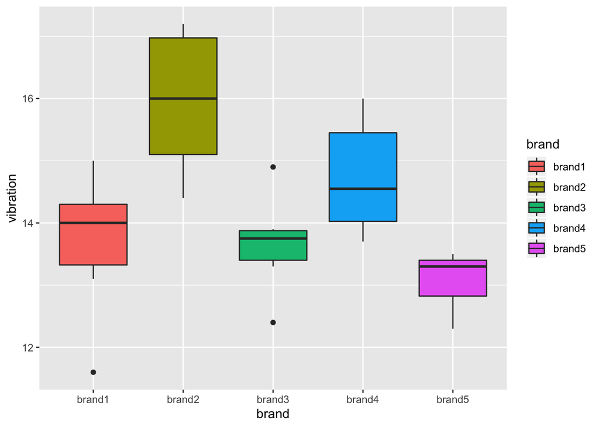

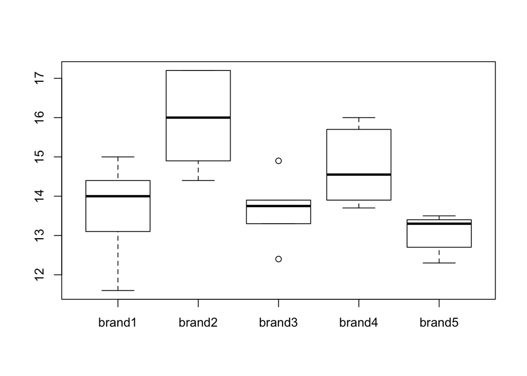

In brand 3, there are two influential outliers.

## f

*Test all possible pairwise t tests (both Unadjusted and adjusted P-value), Tukey HSD, Newman-Keuls, and Scheffe Test. Compare all outputs and report your results.*

| brand | mean |
| --- | --- |
| brand5 | 13.08333 |
| brand3 | 13.66667 |
| brand1 | 13.68333 |
| brand4 | 14.73333 |
| brand2 | 15.95000 |

Means in order:

- Brand 5
- Brand 3
- Brand 1
- Brand 4
- Brand 2

```r
# Pairwise t-test (un-adjusted)
pairwise.t.test(vibration$vibration, vibration$brand, p.adj = "none")
```

```
##
##  Pairwise comparisons using t tests with pooled SD
##
## data:  vibration$vibration and vibration$brand
##
##        brand1  brand2  brand3  brand4
## brand2 0.00038 -       -       -
## brand3 0.97615 0.00035 -       -
## brand4 0.06865 0.03689 0.06464 -
## brand5 0.28728 2.3e-05 0.30058 0.00618
##
## P value adjustment method: none
```

From the unadjusted pairwise t-test output, the groups with similar means are as follows:

- Group 1: Brand 5, Brand 3, Brand 1
- Group 2: Brand 3, Brand 1, Brand 4
- Group 3: Brand 2

```
##
##  Pairwise comparisons using t tests with pooled SD
##
## data:  vibration$vibration and vibration$brand
##
##        brand1  brand2  brand3  brand4
## brand2 0.00376 -       -       -
## brand3 1.00000 0.00348 -       -
## brand4 0.68648 0.36891 0.64642 -
## brand5 1.00000 0.00023 1.00000 0.06184
##
## P value adjustment method: bonferroni
```

From the adjusted pairwise t-test output, using the bonferroni adjustment, the groups with similar means are as follows:

- Group 1: Brand 5, Brand 3, Brand 1, Brand 4
- Group 2: Brand 4, Brand 2

```
##
##  Pairwise comparisons using t tests with pooled SD
##
## data:  vibration$vibration and vibration$brand
##
##        brand1  brand2  brand3  brand4
## brand2 0.00313 -       -       -
## brand3 0.97615 0.00313 -       -
## brand4 0.32321 0.22134 0.32321 -
## brand5 0.86183 0.00023 0.86183 0.04329
##
## P value adjustment method: holm
```

From the adjusted pairwise t-test output, using the holm adjustment, the groups with similar means are as follows:

- Group 1: Brand 5, Brand 3, Brand 1
- Group 2: Brand 3, Brand 1, Brand 4
- Group 3: Brand 4, Brand 2

```
##   Tukey multiple comparisons of means
##     95% family-wise confidence level
##
## Fit: aov(formula = vibration ~ brand, data = vibration)
##
## $brand
##                      diff        lwr        upr     p adj
## brand2-brand1  2.26666667  0.6460270  3.8873064 0.0031588
## brand3-brand1 -0.01666667 -1.6373064  1.6039730 0.9999998
## brand4-brand1  1.05000000 -0.5706397  2.6706397 0.3418272
## brand5-brand1 -0.60000000 -2.2206397  1.0206397 0.8112981
## brand3-brand2 -2.28333333 -3.9039730 -0.6626936 0.0029299
## brand4-brand2 -1.21666667 -2.8373064  0.4039730 0.2106883
## brand5-brand2 -2.86666667 -4.4873064 -1.2460270 0.0002024
## brand4-brand3  1.06666667 -0.5539730  2.6873064 0.3268245
## brand5-brand3 -0.58333333 -2.2039730  1.0373064 0.8262091
## brand5-brand4 -1.65000000 -3.2706397 -0.0293603 0.0445279
```

From the Tukey HSD output, the groups with similar means are as follows:

- Group 1: Brand 5, Brand 3, Brand 1
- Group 2: Brand 3, Brand 1, Brand 4
- Group 3: Brand 4, Brand 2

```
## $statistics
##     MSerror Df     Mean       CV
##   0.9135333 25 14.22333 6.719869
##
## $parameters
##   test name.t ntr alpha
##    SNK  brand   5  0.05
##
## $snk
##      Table CriticalRange
## 2 2.912627      1.136505
## 3 3.522566      1.374503
## 4 3.889997      1.517874
## 5 4.153363      1.620640
##
## $means
##        vibration       std r  Min  Max    Q25   Q50    Q75
## brand1  13.68333 1.1940128 6 11.6 15.0 13.325 14.00 14.300
## brand2  15.95000 1.1674759 6 14.4 17.2 15.100 16.00 16.975
## brand3  13.66667 0.8164966 6 12.4 14.9 13.400 13.75 13.875
## brand4  14.73333 0.9395034 6 13.7 16.0 14.025 14.55 15.450
## brand5  13.08333 0.4792355 6 12.3 13.5 12.825 13.30 13.400
##
## $comparison
## NULL
##
## $groups
##        vibration groups
## brand2  15.95000      a
## brand4  14.73333      b
## brand1  13.68333     bc
## brand3  13.66667     bc
## brand5  13.08333      c
##
## attr(,"class")
## [1] "group"
```

From the Newman-Keuls output, the groups with similar means are as follows:

- Group 1: Brand 5, Brand 3, Brand 1
- Group 2: Brand 3, Brand 1, Brand 4
- Group 3: Brand 2

```
##
## Study: CRD_1c ~ "brand"
##
## Scheffe Test for vibration
##
## Mean Square Error  : 0.9135333
##
## brand,  means
##
##        vibration       std r  Min  Max
## brand1  13.68333 1.1940128 6 11.6 15.0
## brand2  15.95000 1.1674759 6 14.4 17.2
## brand3  13.66667 0.8164966 6 12.4 14.9
## brand4  14.73333 0.9395034 6 13.7 16.0
## brand5  13.08333 0.4792355 6 12.3 13.5
##
## Alpha: 0.05 ; DF Error: 25
## Critical Value of F: 2.75871
##
## Minimum Significant Difference: 1.833094
##
## Means with the same letter are not significantly different.
##
##        vibration groups
## brand2  15.95000      a
## brand4  14.73333     ab
## brand1  13.68333      b
## brand3  13.66667      b
## brand5  13.08333      b
```

From the Scheffe test output, the groups with similar means are as follows:

- Group 1: Brand 5, Brand 3, Brand 1, Brand 4
- Group 2: Brand 4, Brand 2

Comparing all the outputs:

| Brand | Pairwise t-test Unadjusted (Groups) | Pairwise t-test Bonferroni (Groups) | Pairwise t-test Holm (Groups) | Tukey HSD (Groups) | Newman-Keuls (Groups) | Scheffe (Groups) |
| --- | --- | --- | --- | --- | --- | --- |
| 5 | 1 | 1 | 1 | 1 | 1 | 1 |
| 3 | 1, 2 | 1 | 1, 2 | 1, 2 | 1, 2 | 1 |
| 1 | 1, 2 | 1 | 1, 2 | 1, 2 | 1, 2 | 1 |
| 4 | 2 | 1, 2 | 2, 3 | 2, 3 | 2 | 1, 2 |
| 2 | 3 | 2 | 3 | 3 | 3 | 2 |

Comparing the tests:

- Each test consistently puts Brand 2 and Brand 5 in a single group
- Pairwise t-test with a Bonferroni adjustment and the Scheffe test are consistent
- Pairwise t-test with a Holm adjustment and Tukey are consistent
- Pairwise t-test unadjusted and Newman-Keuls are consistent

## g

*Check all basic assumptions for CRD and report your result. If some assumptions are not met, what would you proceed?*

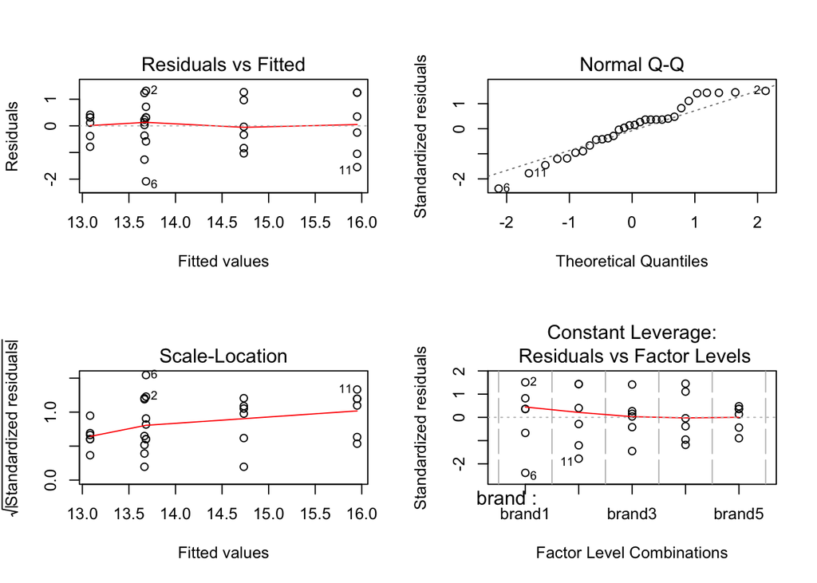

```
##
##  Bartlett test of homogeneity of variances
##
## data:  vibration by brand
## Bartlett's K-squared = 4.0967, df = 4, p-value = 0.3931
```

```
##
##  Shapiro-Wilk normality test
##
## data:  residuals(CRD_1c)
## W = 0.95996, p-value = 0.3091
```

```
##
##  studentized Breusch-Pagan test
##
## data:  CRD_1c
## BP = 4.5697, df = 4, p-value = 0.3344
```

Assumptions:

- Plot of Residuals Versus Fitted Values: There is no obvious pattern in the plot
- Statistical Tests for Equality of Variance: Both Breusch-Pagan and Bartlett test suggest equal variance
- Plotting a normal probability plot of the residuals: The QQ plot and Shapiro-Wilk test suggest normally distributed residuals

# Problem 2

*Members of the golf league at Eastern Electric are looking for a new golf course; the course they’ve used for years has been sold to developers of a retirement community. A search team has gathered the data in golfleague.csv on four local courses; for each course, they have the most recent scores for players like those in the Eastern Electric golf league.*

## a

*Perform an ANOVA to determine whether there is a significant difference in average score among the four local golf courses.*

```
##              Df Sum Sq Mean Sq F value Pr(>F)
## group         3  75024   25008    9611 <2e-16 ***
## Residuals   396   1030       3
## ---
## Signif. codes:  0 '***' 0.001 '**' 0.01 '*' 0.05 '.' 0.1 ' ' 1
```

From the summary of the anova test, the P-value of the hypothesis is less than 0.05, which means we can reject $H_0$ and conclude that the average score is different amongst the different golf courses.

## b

*Check all basic assumptions for CRD and report your result. If some assumptions are not met, perform an alternative test and a posthoc analysis to determine whether there is a significant difference in average score among the four local golf courses.*

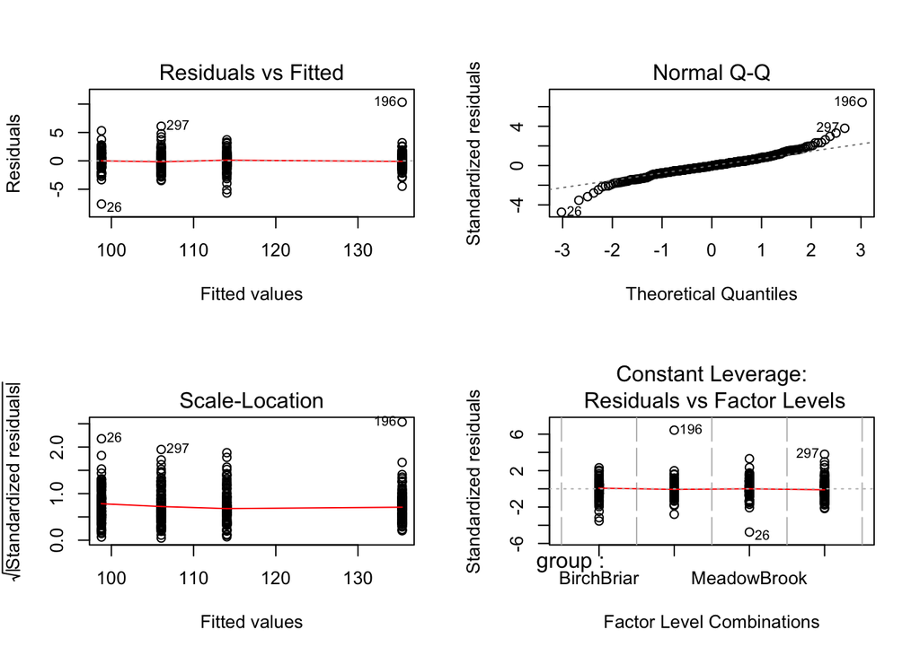

```
##
##  Bartlett test of homogeneity of variances
##
## data:  score by group
## Bartlett's K-squared = 1.3414, df = 3, p-value = 0.7193
```

```
##
##  Shapiro-Wilk normality test
##
## data:  residuals(CRD_2a)
## W = 0.93824, p-value = 7.82e-12
```

```
##
##  studentized Breusch-Pagan test
##
## data:  CRD_2a
## BP = 0.34197, df = 3, p-value = 0.952
```

Assumptions:

- Plot of Residuals Versus Fitted Values: There is no obvious pattern in the plot
- Statistical Tests for Equality of Variance: Both Breusch-Pagan and Bartlett test suggest equal variance
- Plotting a normal probability plot of the residuals: The QQ plot and Shapiro-Wilk test suggest non-normally distributed residuals

Since the assumption that the residuals are normally distributed is rejected, we would need to perform the Kruskal-Wallis test.

```
##
##  Kruskal-Wallis rank sum test
##
## data:  score by group
## Kruskal-Wallis chi-squared = 373.59, df = 3, p-value < 2.2e-16
```

Based on the Kruskal-Wallis test, we can conclude that the average score is different amongst the different courses. The Dunn test will determine which courses are different from each other.

```
## Dunn (1964) Kruskal-Wallis multiple comparison
```

```
##   with no adjustment for p-values.
```

```
##                    Comparison         Z      P.unadj        P.adj
## 1  BirchBriar - Fountainbleau -6.129539 8.813384e-10 8.813384e-10
## 2    BirchBriar - MeadowBrook 12.212597 2.662539e-34 2.662539e-34
## 3 Fountainbleau - MeadowBrook 18.342136 3.815084e-75 3.815084e-75
## 4    BirchBriar - NearCorners  6.095289 1.092397e-09 1.092397e-09
## 5 Fountainbleau - NearCorners 12.224829 2.290639e-34 2.290639e-34
## 6   MeadowBrook - NearCorners -6.117307 9.516977e-10 9.516977e-10
```

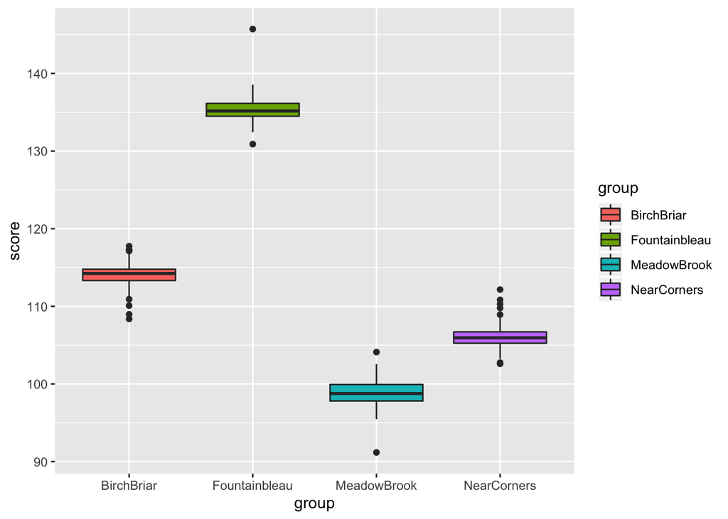

From the Dunn test and the boxplots, the mean scores for all of the courses are different from each other.